# Data Mining Project #1 part II

Karolina Kwasiborska, Tomasz Zaremba, Ziad Al Bkhetan

31 Oct 2015

# Introduction

in this project we will use different classifiers  
* k-nearest neighbors  
* SVM  
* Decision Tree  
* Random Forests  
* Naive Bayes  
then we will evaluate all these classifiers using:  
* ROC Curve  
* Area Under Curve  
* Accuracy using confusion Matrix  
* K-fold cross validation  
* Bootstrap

# Loading data

Starting with data loading into the variable australianDataSet using R script  
Data Link is http://archive.ics.uci.edu/ml/machine-learning-databases/statlog/australian/australian.dat  
in this phase we will divide the dataset into two different sets the first one for classifier training while the second is for the classifier testing.  
* partion percentage is 80:20  
* target attribute to maintain good distribution “A15”

```r
library(lattice)
library(ggplot2)
library(caret)
library(e1071)
library(MASS)
library(kernlab)
library(ROCR)
library(randomForest)
library(grid)
library(party)
library(rpart)
library(survival)
library(Hmisc)
library(klaR)

australianDataSet = read.table("C:\\Users\\Tomek\\Desktop\\Studia\\MSc\\Semestr 2\\Data mining\\Projekty\\1\\australian.dat",
        sep=" ",header=F,col.names=c("A1", "A2", "A3", "A4",
                "A5","A6", "A7", "A8", "A9","A10",
                "A11", "A12", "A13","A14", "A15"),
        fill=FALSE,strip.white=T)

originalaustralianDataSet <-australianDataSet
australianDataSet$A15 <- factor(australianDataSet$A15)
#partitioning
indxTrain <- createDataPartition(y = australianDataSet$A15, p = 0.8)
australianDataSetTrain<- australianDataSet[indxTrain$Resample1,]
australianDataSetTest <- australianDataSet[-indxTrain$Resample1,]
australianDataSetTrain$A15 <- factor(australianDataSetTrain$A15)
```

# Important Attributes Using Random Forests

to choose the suitable model to build our classifiers, we will use random forests to dermine variables importance  
we will use A15 ~ A8 + A14 + A10 + A5 +A7 + A13 + A9.

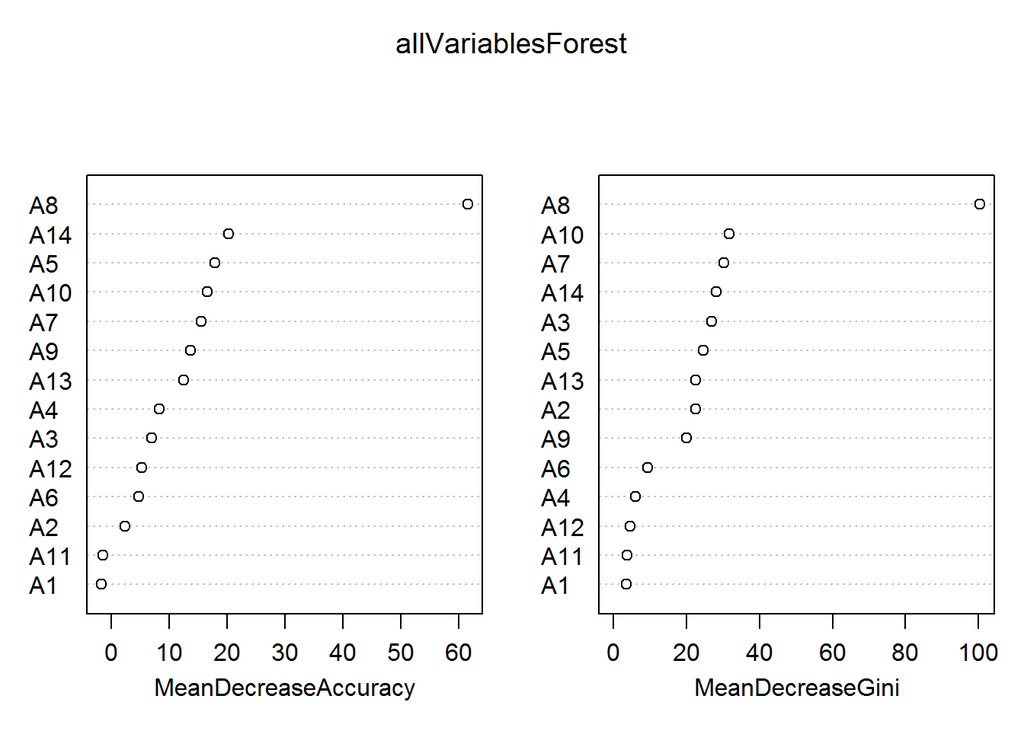

```r
allVariablesForest <- randomForest(A15 ~ ., data = australianDataSet, importance = TRUE, na.action = na.omit)
varImpPlot(allVariablesForest)
```

```r
importance(allVariablesForest)
```

```
##              0          1 MeanDecreaseAccuracy MeanDecreaseGini
## A1  -0.1535344 -2.2094139            -1.716215         3.412436
## A2   2.3823904  0.8462468             2.343575        22.522574
## A3   0.8206349  8.4356233             6.924776        26.765889
## A4   5.5593951  5.8390097             8.284069         6.035071
## A5  12.4061381 13.7674244            17.903153        24.501819
## A6   4.3011612  2.1988652             4.641258         9.270798
## A7  10.8457551  9.8699963            15.439573        30.122074
## A8  53.8830471 50.4382079            61.610100       100.332474
## A9   7.9753385 11.4224302            13.704791        19.988121
## A10 11.3968002 12.9658383            16.554191        31.567501
## A11  1.4775597 -3.3754037            -1.457456         3.775423
## A12 -0.3386590  7.8362010             5.159944         4.476653
## A13  8.8803031  8.9287476            12.440244        22.574366
## A14 16.0807689 12.6580923            20.288592        28.198504
```

# SVM

## Training and testing sets

```r
options(warn=-1)
svm1 <- svm(A15 ~ A8 + A14 + A10 + A5 +A7 + A13 + A9, data = australianDataSetTrain, kernel='linear', cost=10, scale=FALSE, probability = TRUE)
predictions <- predict(svm1, australianDataSetTest)
confusionMatrix <- confusionMatrix(predictions, australianDataSetTest$A15)
confusionMatrix
```

```
## Confusion Matrix and Statistics
##
##           Reference
## Prediction  0  1
##          0 72 22
##          1  4 39
##
##                Accuracy : 0.8102
##                  95% CI : (0.7344, 0.8721)
##     No Information Rate : 0.5547
##     P-Value [Acc > NIR] : 2.828e-10
##
##                   Kappa : 0.6043
##  Mcnemar's Test P-Value : 0.0008561
##
##             Sensitivity : 0.9474
##             Specificity : 0.6393
##          Pos Pred Value : 0.7660
##          Neg Pred Value : 0.9070
##              Prevalence : 0.5547
##          Detection Rate : 0.5255
##    Detection Prevalence : 0.6861
##       Balanced Accuracy : 0.7934
##
##        'Positive' Class : 0
##
```

## K-fold cross validation

```r
train_control <- trainControl(method="cv", number=10)
svm2 <- train(A15 ~ A8 + A14 + A10 + A5 +A7 + A13 + A9, data=australianDataSet, trControl=train_control, method="svmLinear")
predictions <- predict(svm2, australianDataSet)
confusionMatrix <- confusionMatrix(predictions, australianDataSet$A15)
confusionMatrix
```

```
## Confusion Matrix and Statistics
##
##           Reference
## Prediction   0   1
##          0 306  22
##          1  77 285
##
##                Accuracy : 0.8565
##                  95% CI : (0.8281, 0.8818)
##     No Information Rate : 0.5551
##     P-Value [Acc > NIR] : < 2.2e-16
##
##                   Kappa : 0.7146
##  Mcnemar's Test P-Value : 5.724e-08
##
##             Sensitivity : 0.7990
##             Specificity : 0.9283
##          Pos Pred Value : 0.9329
##          Neg Pred Value : 0.7873
##              Prevalence : 0.5551
##          Detection Rate : 0.4435
##    Detection Prevalence : 0.4754
##       Balanced Accuracy : 0.8636
##
##        'Positive' Class : 0
##
```

## Bootstrap

```r
train_control <- trainControl(method="boot", number=10)
svm3 <- train(A15 ~ A8 + A14 + A10 + A5 +A7 + A13 + A9, data=australianDataSet, trControl=train_control, method="svmLinear")
predictions <- predict(svm3, australianDataSet)
confusionMatrix <- confusionMatrix(predictions, australianDataSet$A15)
confusionMatrix
```

```
## Confusion Matrix and Statistics
##
##           Reference
## Prediction   0   1
##          0 306  22
##          1  77 285
##
##                Accuracy : 0.8565
##                  95% CI : (0.8281, 0.8818)
##     No Information Rate : 0.5551
##     P-Value [Acc > NIR] : < 2.2e-16
##
##                   Kappa : 0.7146
##  Mcnemar's Test P-Value : 5.724e-08
##
##             Sensitivity : 0.7990
##             Specificity : 0.9283
##          Pos Pred Value : 0.9329
##          Neg Pred Value : 0.7873
##              Prevalence : 0.5551
##          Detection Rate : 0.4435
##    Detection Prevalence : 0.4754
##       Balanced Accuracy : 0.8636
##
##        'Positive' Class : 0
##
```

# Random forest

## Training and testing sets

```r
forest1 <- randomForest(A15 ~ A8 + A14 + A10 + A5 +A7 + A13 + A9, data = australianDataSetTrain, importance = TRUE, na.action = na.omit)
predictions <- predict(forest1, australianDataSetTest)
confusionMatrix <- confusionMatrix(predictions, australianDataSetTest$A15)
confusionMatrix
```

```
## Confusion Matrix and Statistics
##
##           Reference
## Prediction  0  1
##          0 67  5
##          1  9 56
##
##                Accuracy : 0.8978
##                  95% CI : (0.8345, 0.943)
##     No Information Rate : 0.5547
##     P-Value [Acc > NIR] : <2e-16
##
##                   Kappa : 0.7945
##  Mcnemar's Test P-Value : 0.4227
##
##             Sensitivity : 0.8816
##             Specificity : 0.9180
##          Pos Pred Value : 0.9306
##          Neg Pred Value : 0.8615
##              Prevalence : 0.5547
##          Detection Rate : 0.4891
##    Detection Prevalence : 0.5255
##       Balanced Accuracy : 0.8998
##
##        'Positive' Class : 0
##
```

## K-fold cross validation

```r
train_control <- trainControl(method="cv", number=10)
forest2 <- train(A15 ~ A8 + A14 + A10 + A5 +A7 + A13 + A9, data=australianDataSet, trControl=train_control, method="rf")
predictions <- predict(forest2, australianDataSet)
confusionMatrix <- confusionMatrix(predictions, australianDataSet$A15)
confusionMatrix
```

```
## Confusion Matrix and Statistics
##
##           Reference
## Prediction   0   1
##          0 376  24
##          1   7 283
##
##                Accuracy : 0.9551
##                  95% CI : (0.9368, 0.9693)
##     No Information Rate : 0.5551
##     P-Value [Acc > NIR] : < 2.2e-16
##
##                   Kappa : 0.9085
##  Mcnemar's Test P-Value : 0.004057
##
##             Sensitivity : 0.9817
##             Specificity : 0.9218
##          Pos Pred Value : 0.9400
##          Neg Pred Value : 0.9759
##              Prevalence : 0.5551
##          Detection Rate : 0.5449
##    Detection Prevalence : 0.5797
##       Balanced Accuracy : 0.9518
##
##        'Positive' Class : 0
##
```

## Bootstrap

```r
train_control <- trainControl(method="boot", number=10)
forest3 <- train(A15 ~ A8 + A14 + A10 + A5 +A7 + A13 + A9, data=australianDataSet, trControl=train_control, method="rf")
predictions <- predict(forest3, australianDataSet)
confusionMatrix <- confusionMatrix(predictions, australianDataSet$A15)
confusionMatrix
```

```
## Confusion Matrix and Statistics
##
##           Reference
## Prediction   0   1
##          0 379  26
##          1   4 281
##
##                Accuracy : 0.9565
##                  95% CI : (0.9385, 0.9705)
##     No Information Rate : 0.5551
##     P-Value [Acc > NIR] : < 2.2e-16
##
##                   Kappa : 0.9113
##  Mcnemar's Test P-Value : 0.000126
##
##             Sensitivity : 0.9896
##             Specificity : 0.9153
##          Pos Pred Value : 0.9358
##          Neg Pred Value : 0.9860
##              Prevalence : 0.5551
##          Detection Rate : 0.5493
##    Detection Prevalence : 0.5870
##       Balanced Accuracy : 0.9524
##
##        'Positive' Class : 0
##
```

# Decision tree

## Training and testing sets

```r
# ctree
ctree1 <- ctree(A15 ~ A8 + A14 + A10 + A5 +A7 + A13 + A9, data=australianDataSetTrain)
predictions <- predict(ctree1, australianDataSetTest)
confusionMatrix <- confusionMatrix(predictions, australianDataSetTest$A15)
confusionMatrix
```

```
## Confusion Matrix and Statistics
##
##           Reference
## Prediction  0  1
##          0 61  2
##          1 15 59
##
##                Accuracy : 0.8759
##                  95% CI : (0.8088, 0.926)
##     No Information Rate : 0.5547
##     P-Value [Acc > NIR] : 5.29e-16
##
##                   Kappa : 0.754
##  Mcnemar's Test P-Value : 0.003609
##
##             Sensitivity : 0.8026
##             Specificity : 0.9672
##          Pos Pred Value : 0.9683
##          Neg Pred Value : 0.7973
##              Prevalence : 0.5547
##          Detection Rate : 0.4453
##    Detection Prevalence : 0.4599
##       Balanced Accuracy : 0.8849
##
##        'Positive' Class : 0
##
```

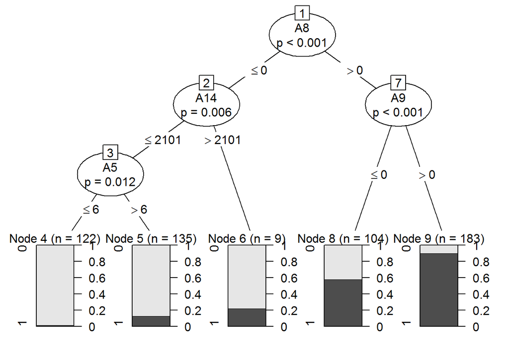

```r
plot(ctree1)
```

```r
# rtree
rtree1 <- rpart(A15 ~ A8 + A14 + A10 + A5 +A7 + A13 + A9, data=australianDataSetTrain, method="class")
predictions <- predict(rtree1, australianDataSetTest)
```

## K-fold cross validation

```r
train_control <- trainControl(method="cv", number=10)

# ctree
ctree2 <- train(A15 ~ A8 + A14 + A10 + A5 +A7 + A13 + A9, data=australianDataSet, trControl=train_control, method="ctree")
predictions <- predict(ctree2, australianDataSet)
confusionMatrix <- confusionMatrix(predictions, australianDataSet$A15)
confusionMatrix
```

```
## Confusion Matrix and Statistics
##
##           Reference
## Prediction   0   1
##          0 359  65
##          1  24 242
##
##                Accuracy : 0.871
##                  95% CI : (0.8437, 0.8951)
##     No Information Rate : 0.5551
##     P-Value [Acc > NIR] : < 2.2e-16
##
##                   Kappa : 0.7354
##  Mcnemar's Test P-Value : 2.235e-05
##
##             Sensitivity : 0.9373
##             Specificity : 0.7883
##          Pos Pred Value : 0.8467
##          Neg Pred Value : 0.9098
##              Prevalence : 0.5551
##          Detection Rate : 0.5203
##    Detection Prevalence : 0.6145
##       Balanced Accuracy : 0.8628
##
##        'Positive' Class : 0
##
```

```r
# rtree
rtree2 <- train(A15 ~ A8 + A14 + A10 + A5 +A7 + A13 + A9, data=australianDataSet, trControl=train_control, method="rpart")
predictions <- predict(rtree2, australianDataSet)
confusionMatrix <- confusionMatrix(predictions, australianDataSet$A15)
confusionMatrix
```

```
## Confusion Matrix and Statistics
##
##           Reference
## Prediction   0   1
##          0 342  40
##          1  41 267
##
##                Accuracy : 0.8826
##                  95% CI : (0.8562, 0.9057)
##     No Information Rate : 0.5551
##     P-Value [Acc > NIR] : <2e-16
##
##                   Kappa : 0.7624
##  Mcnemar's Test P-Value : 1
##
##             Sensitivity : 0.8930
##             Specificity : 0.8697
##          Pos Pred Value : 0.8953
##          Neg Pred Value : 0.8669
##              Prevalence : 0.5551
##          Detection Rate : 0.4957
##    Detection Prevalence : 0.5536
##       Balanced Accuracy : 0.8813
##
##        'Positive' Class : 0
##
```

## Bootstrap

```r
train_control <- trainControl(method="boot", number=10)
# ctree
ctree2 <- train(A15 ~ A8 + A14 + A10 + A5 +A7 + A13 + A9, data=australianDataSet, trControl=train_control, method="ctree")
predictions <- predict(ctree2, australianDataSet)
confusionMatrix <- confusionMatrix(predictions, australianDataSet$A15)
confusionMatrix
```

```
## Confusion Matrix and Statistics
##
##           Reference
## Prediction   0   1
##          0 359  65
##          1  24 242
##
##                Accuracy : 0.871
##                  95% CI : (0.8437, 0.8951)
##     No Information Rate : 0.5551
##     P-Value [Acc > NIR] : < 2.2e-16
##
##                   Kappa : 0.7354
##  Mcnemar's Test P-Value : 2.235e-05
##
##             Sensitivity : 0.9373
##             Specificity : 0.7883
##          Pos Pred Value : 0.8467
##          Neg Pred Value : 0.9098
##              Prevalence : 0.5551
##          Detection Rate : 0.5203
##    Detection Prevalence : 0.6145
##       Balanced Accuracy : 0.8628
##
##        'Positive' Class : 0
##
```

```r
# rtree
rtree2 <- train(A15 ~ A8 + A14 + A10 + A5 +A7 + A13 + A9, data=australianDataSet, trControl=train_control, method="rpart")
predictions <- predict(rtree2, australianDataSet)
confusionMatrix <- confusionMatrix(predictions, australianDataSet$A15)
confusionMatrix
```

```
## Confusion Matrix and Statistics
##
##           Reference
## Prediction   0   1
##          0 342  40
##          1  41 267
##
##                Accuracy : 0.8826
##                  95% CI : (0.8562, 0.9057)
##     No Information Rate : 0.5551
##     P-Value [Acc > NIR] : <2e-16
##
##                   Kappa : 0.7624
##  Mcnemar's Test P-Value : 1
##
##             Sensitivity : 0.8930
##             Specificity : 0.8697
##          Pos Pred Value : 0.8953
##          Neg Pred Value : 0.8669
##              Prevalence : 0.5551
##          Detection Rate : 0.4957
##    Detection Prevalence : 0.5536
##       Balanced Accuracy : 0.8813
##
##        'Positive' Class : 0
##
```

# K Nearest Neighbors

## Data Normalization

while kNN depends on distance calculation between the samples which could be affected by the range of the attributes values, so we normalized all the attributes to reduce this effect.  
Normalization was done using scale function.

```r
australianDataSetNormalized <- australianDataSet
australianDataSetNormalized$A15 <- factor(australianDataSetNormalized$A15)
australianDataSetNormalized$A1 <- scale(australianDataSetNormalized$A1)
australianDataSetNormalized$A2 <- scale(australianDataSetNormalized$A2)
australianDataSetNormalized$A3 <- scale(australianDataSetNormalized$A3)
australianDataSetNormalized$A4 <- scale(australianDataSetNormalized$A4)
australianDataSetNormalized$A5 <- scale(australianDataSetNormalized$A5)
australianDataSetNormalized$A6 <- scale(australianDataSetNormalized$A6)
australianDataSetNormalized$A7 <- scale(australianDataSetNormalized$A7)
australianDataSetNormalized$A8 <- scale(australianDataSetNormalized$A8)
australianDataSetNormalized$A9 <- scale(australianDataSetNormalized$A9)
australianDataSetNormalized$A10 <- scale(australianDataSetNormalized$A10)
australianDataSetNormalized$A11 <- scale(australianDataSetNormalized$A11)
australianDataSetNormalized$A12 <- scale(australianDataSetNormalized$A12)
australianDataSetNormalized$A13 <- scale(australianDataSetNormalized$A13)
australianDataSetNormalized$A14 <- scale(australianDataSetNormalized$A14)
# Training and Testing Datasets
indxTrain <- createDataPartition(y = australianDataSetNormalized$A15, p = 0.8)
australianDataSetNormalizedTrain<- australianDataSetNormalized[indxTrain$Resample1,]
australianDataSetNormalizedTest <- australianDataSetNormalized[-indxTrain$Resample1,]
```

## K-fold cross validation

we will train K nearest neighbors for different 20 values for the parameter k to get the best accuracy, then use this parameter to build the final model.

```r
tlength = 20
train_control <- trainControl(method="cv", number=10)
model <- train(A15 ~ A8 + A14 + A10 + A5 +A7 + A13 + A9, data=australianDataSetNormalizedTrain, trControl=train_control, method="knn", tuneLength = tlength)
klist <-model$bestTune[[1]]
predTab <- predict(model, australianDataSetNormalizedTest )
confusionMatrix(predTab, australianDataSetNormalizedTest$A15)
```

```
## Confusion Matrix and Statistics
##
##           Reference
## Prediction  0  1
##          0 63  7
##          1 13 54
##
##                Accuracy : 0.854
##                  95% CI : (0.7836, 0.9085)
##     No Information Rate : 0.5547
##     P-Value [Acc > NIR] : 7.039e-14
##
##                   Kappa : 0.7073
##  Mcnemar's Test P-Value : 0.2636
##
##             Sensitivity : 0.8289
##             Specificity : 0.8852
##          Pos Pred Value : 0.9000
##          Neg Pred Value : 0.8060
##              Prevalence : 0.5547
##          Detection Rate : 0.4599
##    Detection Prevalence : 0.5109
##       Balanced Accuracy : 0.8571
##
##        'Positive' Class : 0
##
```

```r
confusionMatrix
```

```
## Confusion Matrix and Statistics
##
##           Reference
## Prediction   0   1
##          0 342  40
##          1  41 267
##
##                Accuracy : 0.8826
##                  95% CI : (0.8562, 0.9057)
##     No Information Rate : 0.5551
##     P-Value [Acc > NIR] : <2e-16
##
##                   Kappa : 0.7624
##  Mcnemar's Test P-Value : 1
##
##             Sensitivity : 0.8930
##             Specificity : 0.8697
##          Pos Pred Value : 0.8953
##          Neg Pred Value : 0.8669
##              Prevalence : 0.5551
##          Detection Rate : 0.4957
##    Detection Prevalence : 0.5536
##       Balanced Accuracy : 0.8813
##
##        'Positive' Class : 0
##
```

```r
cvk = model$bestTune[[1]]
```

## Bootstraps

```r
train_control <- trainControl(method="boot", number=10)
model <- train(A15 ~ A8 + A14 + A10 + A5 +A7 + A13 + A9, data=australianDataSetNormalizedTrain, trControl=train_control, method="knn", tuneLength = 20)
predTab <- predict(model, australianDataSetNormalizedTest)
confusionMatrix(predTab, australianDataSetNormalizedTest$A15)
```

```
## Confusion Matrix and Statistics
##
##           Reference
## Prediction  0  1
##          0 66  4
##          1 10 57
##
##                Accuracy : 0.8978
##                  95% CI : (0.8345, 0.943)
##     No Information Rate : 0.5547
##     P-Value [Acc > NIR] : <2e-16
##
##                   Kappa : 0.7951
##  Mcnemar's Test P-Value : 0.1814
##
##             Sensitivity : 0.8684
##             Specificity : 0.9344
##          Pos Pred Value : 0.9429
##          Neg Pred Value : 0.8507
##              Prevalence : 0.5547
##          Detection Rate : 0.4818
##    Detection Prevalence : 0.5109
##       Balanced Accuracy : 0.9014
##
##        'Positive' Class : 0
##
```

```r
confusionMatrix
```

```
## Confusion Matrix and Statistics
##
##           Reference
## Prediction   0   1
##          0 342  40
##          1  41 267
##
##                Accuracy : 0.8826
##                  95% CI : (0.8562, 0.9057)
##     No Information Rate : 0.5551
##     P-Value [Acc > NIR] : <2e-16
##
##                   Kappa : 0.7624
##  Mcnemar's Test P-Value : 1
##
##             Sensitivity : 0.8930
##             Specificity : 0.8697
##          Pos Pred Value : 0.8953
##          Neg Pred Value : 0.8669
##              Prevalence : 0.5551
##          Detection Rate : 0.4957
##    Detection Prevalence : 0.5536
##       Balanced Accuracy : 0.8813
##
##        'Positive' Class : 0
##
```

```r
bk = model$bestTune[[1]]
```

# Naive Bayes

## Data Preparation

```r
aust_equal_size <- originalaustralianDataSet
for (i in c(2, 3, 4, 5, 6, 7, 10, 12, 13, 14)) {
  aust_equal_size[,i]<- cut2(australianDataSet[,i], g=3)
}
aust_equal_size$A15 <- factor(ifelse(aust_equal_size$A15 == 0, "One", "Zero"))
aust_equal_size$A1 <-factor(aust_equal_size$A1)
aust_equal_size$A8 <-factor(aust_equal_size$A8)
aust_equal_size$A9 <-factor(aust_equal_size$A9)
aust_equal_size$A11 <-factor(aust_equal_size$A11)
summary(aust_equal_size)
```

```
##  A1                A2                 A3          A4            A5
##  0:222   [13.8,24.2):230   [0.00, 1.54):239   [1,3):688   [ 1, 7):257
##  1:468   [24.2,34.2):231   [1.54, 5.08):221   3    :  2   [ 7,10):248
##          [34.2,80.2]:229   [5.08,28.00]:230               [10,14]:185
##      A6                   A7      A8      A9          A10      A11
##  [1,5):479   [0.000, 0.335):234   0:329   0:395   0     :395   0:374
##  [5,9]:211   [0.335, 2.040):238   1:361   1:295   1     : 71   1:316
##              [2.040,28.500]:218                   [2,67]:224
##     A12              A13                A14        A15
##  [1,3):682   [  0, 102):242     1         :295   One :383
##  3    :  8   [102, 220):219   [  2,   159):165   Zero:307
##              [220,2000]:229   [159,100001]:230
```

```r
# Partitioning
indxTrain <- createDataPartition(y = aust_equal_size$A15, p = 0.8)
aust_equal_sizeTrain<- aust_equal_size[indxTrain$Resample1,]
aust_equal_sizeTest <- aust_equal_size[-indxTrain$Resample1,]
```

## K-fold cross validation

```r
train_control <- trainControl(method="cv", number=10)
nb_k_model <- train(A15 ~ A8 + A14 + A10 + A5 +A7 + A13 + A9, data=aust_equal_sizeTrain, trControl=train_control, method="nb")
nb_k_predTab <- predict(nb_k_model, aust_equal_sizeTest)
confusionMatrix(nb_k_predTab, aust_equal_sizeTest$A15)
```

```
## Confusion Matrix and Statistics
##
##           Reference
## Prediction One Zero
##       One   67    8
##       Zero   9   53
##
##                Accuracy : 0.8759
##                  95% CI : (0.8088, 0.926)
##     No Information Rate : 0.5547
##     P-Value [Acc > NIR] : 5.29e-16
##
##                   Kappa : 0.7492
##  Mcnemar's Test P-Value : 1
##
##             Sensitivity : 0.8816
##             Specificity : 0.8689
##          Pos Pred Value : 0.8933
##          Neg Pred Value : 0.8548
##              Prevalence : 0.5547
##          Detection Rate : 0.4891
##    Detection Prevalence : 0.5474
##       Balanced Accuracy : 0.8752
##
##        'Positive' Class : One
##
```

```r
confusionMatrix
```

```
## Confusion Matrix and Statistics
##
##           Reference
## Prediction   0   1
##          0 342  40
##          1  41 267
##
##                Accuracy : 0.8826
##                  95% CI : (0.8562, 0.9057)
##     No Information Rate : 0.5551
##     P-Value [Acc > NIR] : <2e-16
##
##                   Kappa : 0.7624
##  Mcnemar's Test P-Value : 1
##
##             Sensitivity : 0.8930
##             Specificity : 0.8697
##          Pos Pred Value : 0.8953
##          Neg Pred Value : 0.8669
##              Prevalence : 0.5551
##          Detection Rate : 0.4957
##    Detection Prevalence : 0.5536
##       Balanced Accuracy : 0.8813
##
##        'Positive' Class : 0
##
```

## Bootstraps

```r
train_control <- trainControl(method="boot", number=10)
nb_b_model <- train(A15 ~ A8 + A14 + A10 + A5 +A7 + A13 + A9, data=aust_equal_sizeTrain, trControl=train_control, method="nb")
nb_b.predTab <- predict(nb_b_model, aust_equal_sizeTest)
confusionMatrix(nb_b.predTab, aust_equal_sizeTest$A15)
```

```
## Confusion Matrix and Statistics
##
##           Reference
## Prediction One Zero
##       One   67    8
##       Zero   9   53
##
##                Accuracy : 0.8759
##                  95% CI : (0.8088, 0.926)
##     No Information Rate : 0.5547
##     P-Value [Acc > NIR] : 5.29e-16
##
##                   Kappa : 0.7492
##  Mcnemar's Test P-Value : 1
##
##             Sensitivity : 0.8816
##             Specificity : 0.8689
##          Pos Pred Value : 0.8933
##          Neg Pred Value : 0.8548
##              Prevalence : 0.5547
##          Detection Rate : 0.4891
##    Detection Prevalence : 0.5474
##       Balanced Accuracy : 0.8752
##
##        'Positive' Class : One
##
```

```r
confusionMatrix
```

```
## Confusion Matrix and Statistics
##
##           Reference
## Prediction   0   1
##          0 342  40
##          1  41 267
##
##                Accuracy : 0.8826
##                  95% CI : (0.8562, 0.9057)
##     No Information Rate : 0.5551
##     P-Value [Acc > NIR] : <2e-16
##
##                   Kappa : 0.7624
##  Mcnemar's Test P-Value : 1
##
##             Sensitivity : 0.8930
##             Specificity : 0.8697
##          Pos Pred Value : 0.8953
##          Neg Pred Value : 0.8669
##              Prevalence : 0.5551
##          Detection Rate : 0.4957
##    Detection Prevalence : 0.5536
##       Balanced Accuracy : 0.8813
##
##        'Positive' Class : 0
##
```

# ROC (Receiver Operating Characteristics)

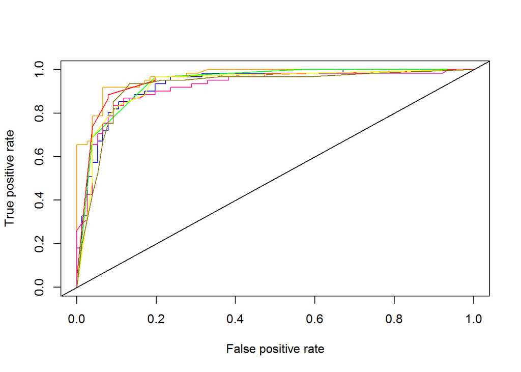

```r
# SVM
svm.prob <- attributes(predict(svm1, newdata=australianDataSetTest, probability = TRUE))$probabilities[, 2]
svm.fit.pred =  prediction(svm.prob, australianDataSetTest$A15)
svm.fit.perf = performance(svm.fit.pred, 'tpr', 'fpr')
plot(svm.fit.perf, col="blue3")

# Random forst
rf.prob <- predict(forest1, australianDataSetTest, type="prob")[,2]
rf.fit.pred = prediction(rf.prob, australianDataSetTest$A15)
rf.fit.perf = performance(rf.fit.pred,"tpr","fpr")
plot(rf.fit.perf, col="orange", add=TRUE)

# Decision tree
ctree.prob <- do.call(rbind, predict(ctree1, newdata=australianDataSetTest, type="prob"))
ctree.fit.pred <- prediction(ctree.prob[,2], australianDataSetTest$A15)
ctree.fit.perf = performance(ctree.fit.pred,"tpr","fpr")
plot(ctree.fit.perf, col="green", add=TRUE)

rtree.prob <- predict(rtree1, newdata=australianDataSetTest, type="prob")
rtree.fit.pred <- prediction(rtree.prob[,2], australianDataSetTest$A15)
rtree.fit.perf = performance(rtree.fit.pred,"tpr","fpr")
plot(rtree.fit.perf, col="red", add=TRUE)

# NB
predTabPro <- predict(nb_k_model, aust_equal_sizeTest, type="prob")[, 2]
nb_k.fit.pred <- prediction(predTabPro, aust_equal_sizeTest$A15)
nb_k.fit.pref <- performance(nb_k.fit.pred, "tpr", "fpr")
nb_k.fit_auc = performance(nb_k.fit.pred,"auc")
plot(nb_k.fit.pref, col="cyan", add=TRUE)

predTab1 <- predict(nb_b_model, aust_equal_sizeTest, type="prob")[, 2]
nb_b.fit.pred <- prediction(predTab1, aust_equal_sizeTest$A15)
nb_b.fit.pref <- performance(nb_b.fit.pred, "tpr", "fpr")
nb_b.fit_auc = performance(nb_b.fit.pred,"auc")
plot(nb_b.fit.pref, col="deeppink", add=TRUE)

# KNN
for(k in c(cvk, bk))
{
  knn <- knn3(A15 ~ A8 + A14 + A10 + A5 +A7 + A13 + A9, data=australianDataSetNormalizedTrain, k = k )
  kntab <- predict(knn, newdata = australianDataSetNormalizedTest, type="prob")[, 2]
  fit.pred <- prediction(kntab, australianDataSetNormalizedTest$A15)
  fit.pref <- performance(fit.pred, "tpr", "fpr")
  fit.perf_auc = performance(fit.pred,"auc")
  if (k == cvk)
  {
    kfknn_auc<-fit.perf_auc@y.values[[1]]
    plot(fit.pref, col="yellow", add=TRUE)
  }
  else
  {
    bknn_auc<-fit.perf_auc@y.values[[1]]
    plot(fit.pref, col="gold4", add = TRUE)
  }
}
abline(a=0, b=1)
```

LEGEND:  
SVM - blue  
Random Forest - orange  
Decision tree - green, red  
Naive Bayes - cyan, pink  
KNN - yellow, gold

# AUC (Area Under the Curve)

the area under the curve for all classifers

## SVM

```r
svm.fit.perf = performance(svm.fit.pred,"auc")
svm.fit.perf@y.values[[1]]
```

```
## [1] 0.9333477
```

## Random forest

```r
rf.fit.perf = performance(rf.fit.pred,"auc")
rf.fit.perf@y.values[[1]]
```

```
## [1] 0.9682916
```

## Decision tree

```r
ctree.fit.perf = performance(ctree.fit.pred,"auc")
ctree.fit.perf@y.values[[1]]
```

```
## [1] 0.9406816
```

```r
rtree.fit.perf = performance(rtree.fit.pred,"auc")
rtree.fit.perf@y.values[[1]]
```

```
## [1] 0.9454271
```

## K Nearest Neighbors

```r
kfknn_auc
```

```
## [1] 0.9312985
```

```r
bknn_auc
```

```
## [1] 0.9219154
```

## Naive Bays

```r
nb_b.fit_auc@y.values[[1]]
```

```
## [1] 0.9213762
```

```r
nb_k.fit_auc@y.values[[1]]
```

```
## [1] 0.9213762
```